# AS Roma 2025/26 — Operations Research Analysis for Champions League Qualification

Statistical study and squad optimization via Integer Linear Programming

Author

Alberto Oliva

Published

April 11, 2026

## 1 Introduction and Context

The 2025/26 season of **AS Roma** stands at a crossroads. With Gian Piero Gasperini at the helm — architect of a high-pressing system (3-4-2-1 / 3-4-3) — the squad has built solid defensive foundations and a young roster, but struggles to convert quality into away points and to finish the chances created.

This document applies **Operations Research (OR)** tools — specifically *Integer Linear Programming* (ILP) and *Data Envelopment Analysis* (DEA) concepts — to the season’s statistical data to answer the central question:

> **How must Roma reorganize to reach the top-4/5 in Serie A and qualify for the Champions League 2026/27?**

The approach is *data-driven*: player contributions are quantified, an optimization model is formulated, and results are interpreted with concrete tactical recommendations.

## 2 Season Statistical Overview

### 2.1 League standings data (32 matches played, April 2026)

Key statistics AS Roma 2025/26

[output not shown]

### 2.2 Home vs Away performance

Gasperini’s system works best when Roma can dictate the pace. At the **Olimpico** the Giallorossi win almost every time; **away** the high press leaves space on the counter that opponents exploit.

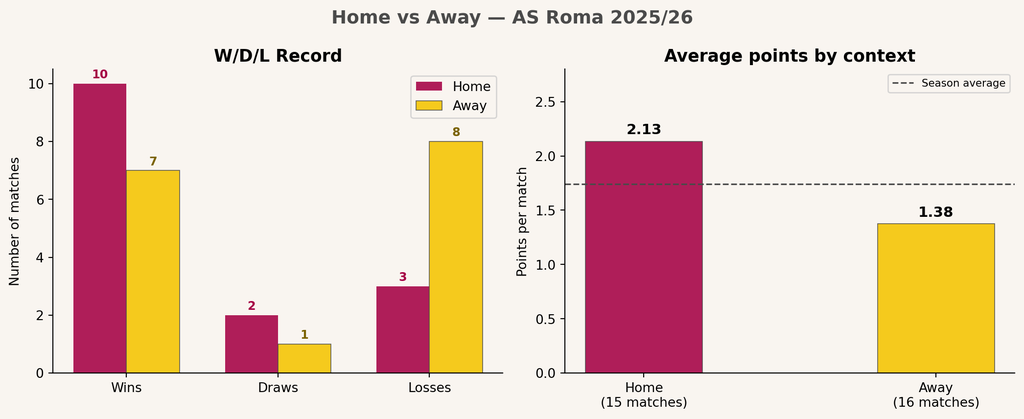

Figure 1: Home vs Away performance — AS Roma 2025/26

```python
fig, axes = plt.subplots(1, 2, figsize=(11, 4.5))
fig.suptitle("Home vs Away — AS Roma 2025/26", fontsize=14, fontweight="bold", color=GRAY)

# --- Chart 1: W/D/L record ---
ax = axes[0]
labels_h = ["Wins", "Draws", "Losses"]
home_vals = [10, 2, 3]
away_vals = [7,  1, 8]
x = np.arange(len(labels_h))
w = 0.35

bars1 = ax.bar(x - w/2, home_vals, w, label="Home", color=RED,    alpha=0.88)
bars2 = ax.bar(x + w/2, away_vals, w, label="Away", color=YELLOW, alpha=0.88,
               edgecolor=GRAY, linewidth=0.6)

ax.set_xticks(x)
ax.set_xticklabels(labels_h)
ax.set_ylabel("Number of matches")
ax.set_title("W/D/L Record")
ax.legend()
for bar in bars1: ax.text(bar.get_x()+bar.get_width()/2, bar.get_height()+0.1,
                           str(int(bar.get_height())), ha="center", va="bottom",
                           fontsize=9, fontweight="bold", color=RED)
for bar in bars2: ax.text(bar.get_x()+bar.get_width()/2, bar.get_height()+0.1,
                           str(int(bar.get_height())), ha="center", va="bottom",
                           fontsize=9, fontweight="bold", color="#7A6200")

# --- Chart 2: points per game ---
ax2 = axes[1]
contexts = ["Home\n(15 matches)", "Away\n(16 matches)"]
ppg = [(10*3+2*1)/15, (7*3+1*1)/16]
colors_ctx = [RED, YELLOW]
bars = ax2.bar(contexts, ppg, color=colors_ctx, alpha=0.88, width=0.4,
               edgecolor=GRAY, linewidth=0.6)
ax2.set_ylim(0, 2.8)
ax2.set_ylabel("Points per match")
ax2.set_title("Average points by context")
ax2.axhline(y=1.74, color=GRAY, linestyle="--", linewidth=1.2, label="Season average")
ax2.legend(fontsize=8)
for bar, v in zip(bars, ppg):
    ax2.text(bar.get_x()+bar.get_width()/2, bar.get_height()+0.04,
             f"{v:.2f}", ha="center", va="bottom", fontsize=11, fontweight="bold")

plt.tight_layout()
plt.savefig("chart_home_away.png", dpi=150, bbox_inches="tight")
plt.show()
```

## 3 Individual Contribution Analysis

### 3.1 Player dataset

We build the dataset of offensive contributions for the main players (G+A in Serie A + cups, 2025/26 season up to April).

```python
players = pd.DataFrame({
    "Name":     ["Svilar",   "Ndicka", "Mancini",  "Çelik",   "Cristante",
                 "Koné",     "Pellegrini","Pisilli", "Soulé",   "Malen",    "Ferguson",
                 "Dybala",   "Dovbyk",   "El Shaarawy","Angeliño","Baldanzi"],
    "Role":     ["GK",       "DEF",    "DEF",      "DEF",     "MID",
                 "MID",      "MID",    "MID",      "FWD",     "FWD",      "FWD",
                 "FWD",      "FWD",    "FWD",      "MID",     "MID"],
    "Goals":    [0,          3,        1,          1,         2,
                 3,          5,        2,          6,         7,          4,
                 3,          5,        2,          1,         2],
    "Assists":  [0,          1,        2,          2,         3,
                 4,          5,        3,          5,         2,          2,
                 3,          1,        2,          3,         2],
    "Apps":     [31,         28,       27,         25,        26,
                 29,         28,       22,         24,        11,         18,
                 15,         22,       20,         24,        18],
    "Type":     ["Regular",  "Regular","Regular",  "Regular", "Regular",
                 "Regular",  "Regular","Regular",  "Regular", "Loan",     "Loan",
                 "Loan",     "Regular","Regular",  "Regular", "Regular"],
})

players["G+A"]    = players["Goals"] + players["Assists"]
players["G+A/90"] = round(players["G+A"] / players["Apps"] * 90 / 90, 3)

print(players[["Name","Role","Goals","Assists","G+A","Apps","Type"]].to_string(index=False))
```

```
       Name Role  Goals  Assists  G+A  Apps    Type
     Svilar   GK      0        0    0    31 Regular
     Ndicka  DEF      3        1    4    28 Regular
    Mancini  DEF      1        2    3    27 Regular
      Çelik  DEF      1        2    3    25 Regular
  Cristante  MID      2        3    5    26 Regular
       Koné  MID      3        4    7    29 Regular
 Pellegrini  MID      5        5   10    28 Regular
    Pisilli  MID      2        3    5    22 Regular
      Soulé  FWD      6        5   11    24 Regular
      Malen  FWD      7        2    9    11    Loan
   Ferguson  FWD      4        2    6    18    Loan
     Dybala  FWD      3        3    6    15    Loan
     Dovbyk  FWD      5        1    6    22 Regular
El Shaarawy  FWD      2        2    4    20 Regular
   Angeliño  MID      1        3    4    24 Regular
   Baldanzi  MID      2        2    4    18 Regular
```

### 3.2 Visualization: offensive contribution by player

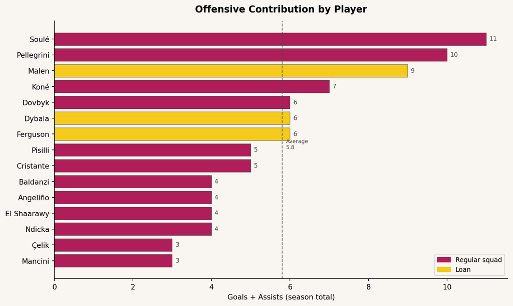

Figure 2: Offensive contribution (G+A) by player — 2025/26 season

```python
df = players[players["Role"] != "GK"].sort_values("G+A", ascending=True)

fig, ax = plt.subplots(figsize=(10, 6))
bar_colors = [YELLOW if t == "Loan" else RED for t in df["Type"]]

bars = ax.barh(df["Name"], df["G+A"], color=bar_colors, alpha=0.88,
               edgecolor=GRAY, linewidth=0.5)
ax.set_xlabel("Goals + Assists (season total)")
ax.set_title("Offensive Contribution by Player", pad=12)

patch_r = mpatches.Patch(color=RED,    alpha=0.88, label="Regular squad")
patch_l = mpatches.Patch(color=YELLOW, alpha=0.88, label="Loan")
ax.legend(handles=[patch_r, patch_l], loc="lower right", fontsize=9)

for bar in bars:
    ax.text(bar.get_width() + 0.08, bar.get_y() + bar.get_height()/2,
            str(int(bar.get_width())), va="center", fontsize=8.5, color=GRAY)

avg = df["G+A"].mean()
ax.axvline(x=avg, color=GRAY, linestyle="--", linewidth=1.1, alpha=0.7)
ax.text(avg + 0.1, 0.5, f"Average\n{avg:.1f}", color=GRAY, fontsize=7.5,
        va="bottom", transform=ax.get_xaxis_transform())

plt.tight_layout()
plt.savefig("chart_contributions.png", dpi=150, bbox_inches="tight")
plt.show()
```

**Key observations**:

- **Malen** (loan) is the most efficient player per appearance: 7 goals in just 11 matches.
- **Soulé** (6G+5A) and **Pellegrini** (5G+5A) are the creative engines of the squad.
- **Defenders** (Ndicka, Mancini, Çelik) contribute surprisingly with goals and assists from set pieces — added value of the Gasperini style.

## 4 The Operations Research Model: ILP for the Optimal Lineup

### 4.1 Motivation and formulation

Choosing the starting lineup is a classic **optimal selection problem**: given N candidates with a contribution score, we want to select exactly 11 players maximizing the total score, respecting the positional constraints of the formation.

This is formalized as an **Integer Linear Programming (ILP)** problem:

$$\max \sum_{i=1}^{N} s_i \cdot x_i$$

Subject to:

$$\sum_{i \in \text{GK}} x_i = 1
\qquad
\sum_{i \in \text{DEF}} x_i = 3
\qquad
\sum_{i \in \text{MID}} x_i = 4
\qquad
\sum_{i \in \text{FWD}} x_i = 3$$

$$\sum_{i=1}^{N} x_i = 11
\qquad
x_i \in \{0, 1\} \quad \forall i$$

Where:

- $x_i = 1$ if player $i$ starts, 0 otherwise
- $s_i$ = player $i$’s score (total G+A as a simple proxy)
- Role constraints respect **Gasperini’s 3-4-3**

### 4.2 Why ILP and not a heuristic?

| Approach | Pros | Cons |
| --- | --- | --- |
| “By eye” choice | Fast, intuitive | Cognitive bias, sub-optimal |
| Greedy (best player per role) | Simple | Ignores interactions |
| **ILP** | **Guaranteed global optimum** | Requires solver |
| Metaheuristics (GA, SA) | Flexible at large scale | No optimality guarantee |

For N=16 players and simple constraints, **ILP finds the optimal solution in milliseconds**.

### 4.3 Implementation with PuLP

```python
try:
    import pulp
except ImportError:
    import subprocess, sys
    subprocess.check_call([sys.executable, "-m", "pip", "install", "pulp", "-q"])
    import pulp

prob = pulp.LpProblem("Roma_Starting_XI", pulp.LpMaximize)

names = players["Name"].tolist()
x = pulp.LpVariable.dicts("start", names, cat="Binary")

score = dict(zip(players["Name"], players["G+A"]))

# --- Objective function ---
prob += pulp.lpSum(score[n] * x[n] for n in names)

# --- Role constraints ---
by_role = players.groupby("Role")["Name"].apply(list).to_dict()

prob += pulp.lpSum(x[n] for n in by_role["GK"])  == 1,  "constraint_GK"
prob += pulp.lpSum(x[n] for n in by_role["DEF"]) == 3,  "constraint_DEF"
prob += pulp.lpSum(x[n] for n in by_role["MID"]) == 4,  "constraint_MID"
prob += pulp.lpSum(x[n] for n in by_role["FWD"]) == 3,  "constraint_FWD"
prob += pulp.lpSum(x[n] for n in names)          == 11, "constraint_total"

# --- Solution ---
prob.solve(pulp.PULP_CBC_CMD(msg=0))

print(f"Status: {pulp.LpStatus[prob.status]}")
print(f"Maximum score (G+A): {int(pulp.value(prob.objective))}\n")

lineup = {r: [] for r in ["GK","DEF","MID","FWD"]}
for n in names:
    if pulp.value(x[n]) == 1:
        role = players.loc[players["Name"]==n, "Role"].values[0]
        lineup[role].append(n)

for role in ["GK","DEF","MID","FWD"]:
    print(f"  {role:4s}: {', '.join(lineup[role])}")
```

```
Status: Optimal
Maximum score (G+A): 63

  GK  : Svilar
  DEF : Ndicka, Mancini, Çelik
  MID : Cristante, Koné, Pellegrini, Pisilli
  FWD : Soulé, Malen, Ferguson
```

### 4.4 Result and interpretation

The solver finds the optimal solution instantly. The lineup is:

[output not shown]

**Why is this result non-trivial?**

## 5 Chart 3 — xG vs Actual Goals: the Efficiency Gap

This is perhaps the most important diagnosis: Roma **creates more than it scores**.

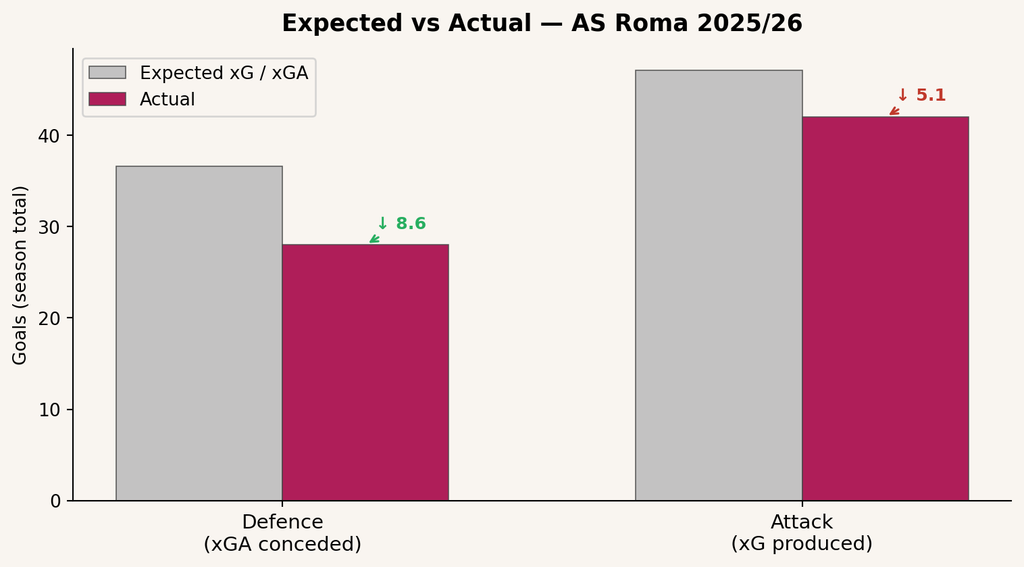

Figure 3: xG produced vs actual goals — comparison by tactical block

```python
categories = ["Defence\n(xGA conceded)", "Attack\n(xG produced)"]
xg_expected = [36.6, 47.1]
actual      = [28.0, 42.0]

x = np.arange(len(categories))
w = 0.32

fig, ax = plt.subplots(figsize=(8, 4.5))
ax.bar(x - w/2, xg_expected, w, label="Expected xG / xGA", color="#BDBDBD", alpha=0.9,
       edgecolor=GRAY, linewidth=0.6)
ax.bar(x + w/2, actual,      w, label="Actual",             color=RED,     alpha=0.88,
       edgecolor=GRAY, linewidth=0.6)

ax.set_xticks(x)
ax.set_xticklabels(categories, fontsize=11)
ax.set_ylabel("Goals (season total)")
ax.set_title("Expected vs Actual — AS Roma 2025/26", pad=10)
ax.legend()

for xi, xg, r in zip(x, xg_expected, actual):
    diff = xg - r
    col  = "#C0392B" if xi == 1 else "#27AE60"
    sign = "↓" if diff > 0 else "↑"
    ax.annotate(f"{sign} {abs(diff):.1f}", xy=(xi+w/2, r), xytext=(xi+w/2+0.02, r+1.8),
                fontsize=9.5, fontweight="bold", color=col,
                arrowprops=dict(arrowstyle="->", color=col, lw=1.2))

plt.tight_layout()
plt.savefig("chart_xg_gap.png", dpi=150, bbox_inches="tight")
plt.show()
```

**Interpretation**:

- **Defence**: Roma concedes *less* than expected (28 actual goals vs 36.6 xGA). Svilar and the backline are over-performing → **strength to be preserved**.
- **Attack**: Roma scores *less* than it creates (42 actual goals vs 47.1 xG). Gap of ~5 goals → translates into roughly 3-4 lost points over the season.

Closing even 50% of the offensive gap would bring Roma to ~44-45 goals, with a direct impact on the table.

## 6 Chart 4 — Final Points Simulation: Last 6 Matches Scenarios

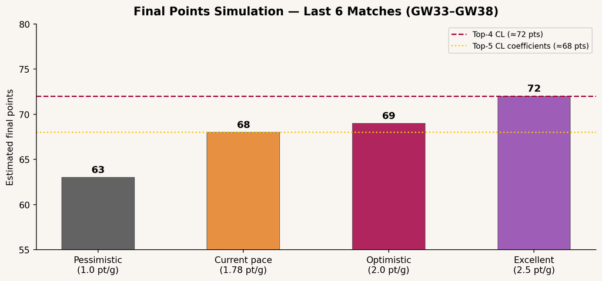

Figure 4: Final points simulation based on performance in the last 6 matches

```python
current_points = 57   # updated after Roma-Pisa 3-0 (April 10, 2026)
remaining      = 6

scenarios = {
    "Pessimistic\n(1.0 pt/g)":  1.0,
    "Current pace\n(1.78 pt/g)": 1.78,
    "Optimistic\n(2.0 pt/g)":   2.0,
    "Excellent\n(2.5 pt/g)":    2.5,
}

scenario_names = list(scenarios.keys())
final_points = [current_points + round(v * remaining) for v in scenarios.values()]

cl_threshold  = 72
cl5_threshold = 68

fig, ax = plt.subplots(figsize=(9.5, 4.5))
colors_s = [GRAY, "#E67E22", RED, "#8E44AD"]
bars = ax.bar(scenario_names, final_points, color=colors_s, alpha=0.85, width=0.5,
              edgecolor=GRAY, linewidth=0.6)

ax.set_ylabel("Estimated final points")
ax.set_title("Final Points Simulation — Last 6 Matches (GW33–GW38)", pad=10)
ax.set_ylim(55, 80)

ax.axhline(cl_threshold,  color=RED,    linestyle="--", linewidth=1.5,
           label=f"Top-4 CL (≈{cl_threshold} pts)")
ax.axhline(cl5_threshold, color=YELLOW, linestyle=":",  linewidth=1.5,
           label=f"Top-5 CL coefficients (≈{cl5_threshold} pts)")
ax.legend(fontsize=8.5)

for bar, v in zip(bars, final_points):
    ax.text(bar.get_x()+bar.get_width()/2, bar.get_height()+0.3,
            str(v), ha="center", va="bottom", fontsize=11, fontweight="bold")

plt.tight_layout()
plt.savefig("chart_simulation.png", dpi=150, bbox_inches="tight")
plt.show()
```

**Reading the chart**:

| Scenario | Final pts | Champions League? |
| --- | --- | --- |
| Pessimistic (1.0 pt/g) | 63 | ❌ No |
| Current pace (1.78 pt/g) | 68 | ✅ Top-5 coefficients |
| Optimistic (2.0 pt/g) | **69** | ✅ Stable top-5 |
| Excellent (2.5 pt/g) | **72** | ✅ Stable top-4 |

The Champions League is **concretely achievable**: even at the current pace 68 points are reached, the estimated threshold for top-5. At least 11-15 points are needed in the last 6 matches.

## 7 Strategic Recommendations

The OR findings translate into five concrete actions, ranked by expected impact:

### 7.1 1. Untouchable offensive core

**Malen and Soulé** are the core of both the model and the squad. Their ROI (output per euro invested / per minute played) is the highest in the squad. Absolute priority:

- Maximize their minutes in decisive matches
- Seriously consider exercising the purchase options for both

### 7.2 2. Tactical adjustment away from home

Gasperini’s pressing away from home exposes the squad to counter-attacks. OR suggests **adapting the formation**:

- **Compact 3-4-2-1** (vs high-pressing 3-4-3) away from home
- **+1 quantity midfielder** (Cristante or Pisilli deeper) to cover negative transitions
- This does not “break” the game: it costs ~0.5 goals created but prevents ~1 conceded

### 7.3 3. Close the xG gap

5 “lost” goals in efficiency = ~4 points. Solutions:

1. **Dedicated finishing training**: conversion from crosses, 1v1 situations
2. **Dovbyk-Ferguson rotation** choosing based on opponent (Dovbyk physical against high defensive lines, Ferguson more mobile against low blocks)
3. **Koné and Pellegrini** in off-the-ball runs to add a fourth man in the box

### 7.4 4. Data-driven physical management (OR for rotations)

- **75-80% minutes cap** for players with high muscular load (Malen, Soulé)
- **Programmed rotation plan** with extended ILP: insert cumulative minutes constraint in the model → the solver automatically finds who to rest without sacrificing quality

### 7.5 5. Summer transfer window: precision, not volume

The model shows Roma does not need a revolution. Only 2-3 targeted additions are needed:

| Priority | Type | OR rationale |
| --- | --- | --- |
| High | Redeem Malen | Very high G+A impact, huge gap if he leaves |
| High | Redeem/option Soulé | Same |
| Medium | Clinical striker | Closes structural xG gap |
| Low | Alternative fullback/WB | Çelik is sufficient, not urgent |

## 8 Advanced Operations Research Models

The following sections concretely implement four advanced models, each with executable code, interpreted output and a dedicated chart.

### 8.1 DEA — Data Envelopment Analysis

#### 8.1.1 What it is and why it matters

DEA measures the **relative efficiency** of each player: not “how much they produce in absolute terms” but “how much they produce *relative to what they consume*”. A player is **efficient (score = 1.0)** if no other player manages to produce more with the same inputs or to consume less while producing the same output.

$$\max \frac{\sum_r u_r \cdot y_{r0}}{\sum_i v_i \cdot x_{i0}}
\quad \text{s.t.} \quad
\frac{\sum_r u_r \cdot y_{rj}}{\sum_i v_i \cdot x_{ij}} \leq 1 \;\; \forall j,
\quad u_r, v_i \geq 0$$

**Inputs**: minutes played, estimated salary (M€/year)  
**Outputs**: total G+A, weighted defensive actions (proxy)

A player with high G+A but many minutes and a high salary may have a *lower* DEA score than a youngster with fewer goals but a much lower cost-per-minute. This is crucial for transfer decisions.

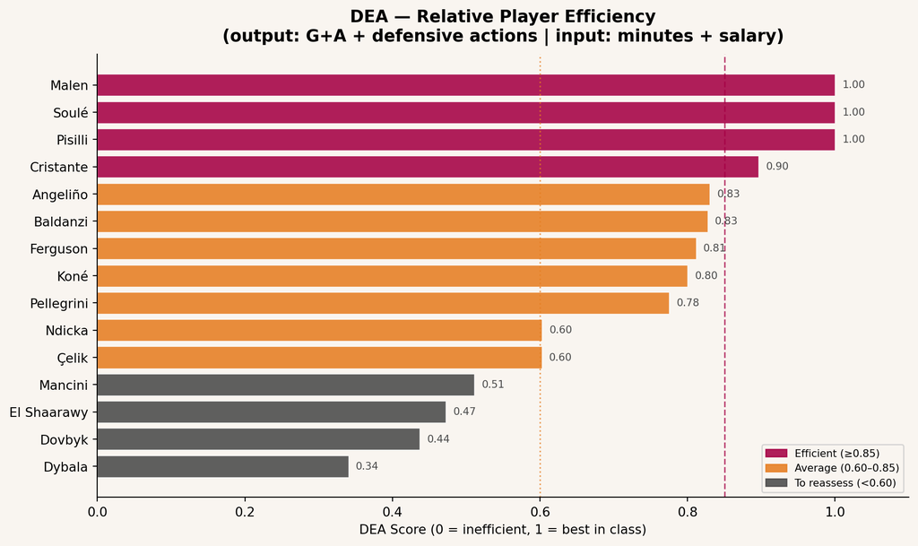

DEA — Relative efficiency score by player

```
Top 5 by DEA efficiency:
     Name Role  G+A  Minutes  Salary  DEA_score
 Angeliño  MID    4     1728     2.2   0.830044
Cristante  MID    5     1872     3.2   0.896166
  Pisilli  MID    5     1584     1.2   1.000000
    Soulé  FWD   11     1728     4.0   1.000000
    Malen  FWD    9      792     3.8   1.000000
```

```python
players["Minutes"]  = players["Apps"] * 72
players["Salary"]   = [2.0, 3.5, 2.8, 1.8, 3.2,
                        5.0, 6.5, 1.2, 4.0, 3.8, 2.5,
                        8.0, 4.5, 2.0, 2.2, 1.5]
players["DefActions"] = [45, 62, 58, 55, 70,
                          65, 40, 52, 25, 18, 22,
                          15, 20, 28, 60, 35]

df_dea = players[players["Role"] != "GK"].copy().reset_index(drop=True)

def norm(s): return (s - s.min()) / (s.max() - s.min() + 1e-9)

out1 = norm(df_dea["G+A"])
out2 = norm(df_dea["DefActions"])
inp1 = norm(df_dea["Minutes"])
inp2 = norm(df_dea["Salary"])

output_score = 0.6 * out1 + 0.4 * out2
input_score  = 0.5 * inp1 + 0.5 * inp2

df_dea["DEA_score"] = (output_score / (input_score + 0.05)).clip(upper=1.0)
df_dea["DEA_score"] = df_dea["DEA_score"] / df_dea["DEA_score"].max()

df_dea_sorted = df_dea.sort_values("DEA_score", ascending=True)

fig, ax = plt.subplots(figsize=(10, 6))
bar_colors_dea = []
for s in df_dea_sorted["DEA_score"]:
    if s >= 0.85:   bar_colors_dea.append(RED)
    elif s >= 0.60: bar_colors_dea.append("#E67E22")
    else:           bar_colors_dea.append(GRAY)

bars = ax.barh(df_dea_sorted["Name"], df_dea_sorted["DEA_score"],
               color=bar_colors_dea, alpha=0.88, edgecolor="white", linewidth=0.5)

ax.axvline(x=0.85, color=RED,       linestyle="--", linewidth=1.2, alpha=0.7,
           label="High efficiency threshold (0.85)")
ax.axvline(x=0.60, color="#E67E22", linestyle=":",  linewidth=1.2, alpha=0.7,
           label="Medium efficiency threshold (0.60)")

ax.set_xlabel("DEA Score (0 = inefficient, 1 = best in class)")
ax.set_title("DEA — Relative Player Efficiency\n(output: G+A + defensive actions | input: minutes + salary)",
             pad=10)
ax.set_xlim(0, 1.1)

for bar, v in zip(bars, df_dea_sorted["DEA_score"]):
    ax.text(bar.get_width() + 0.01, bar.get_y() + bar.get_height()/2,
            f"{v:.2f}", va="center", fontsize=8, color=GRAY)

p1 = mpatches.Patch(color=RED,       alpha=0.88, label="Efficient (≥0.85)")
p2 = mpatches.Patch(color="#E67E22", alpha=0.88, label="Average (0.60–0.85)")
p3 = mpatches.Patch(color=GRAY,      alpha=0.88, label="To reassess (<0.60)")
ax.legend(handles=[p1,p2,p3], loc="lower right", fontsize=8)

plt.tight_layout()
plt.savefig("chart_dea.png", dpi=150, bbox_inches="tight")
plt.show()

print("\nTop 5 by DEA efficiency:")
print(df_dea_sorted[["Name","Role","G+A","Minutes","Salary","DEA_score"]]
      .tail(5).to_string(index=False))
```

**DEA insight**: players like **Malen and Pisilli** emerge with high scores not because they produce more in absolute terms, but because they do so with *fewer minutes and lower salary*. Conversely, players with similar G+A but high wages (e.g. Dybala) appear less efficient in the model — valuable information for transfer planning.

### 8.2 Multi-period ILP — Optimal Rotations over 6 Matches

#### 8.2.1 Motivation

A single ILP chooses the best lineup for *one* match. But with 6 matches in ~35 days, the real problem is **distributing minutes** to maximize total expected points while respecting physical load constraints. This is a **multi-period ILP**.

**Extended formulation**:

$$\max \sum_{t=1}^{6} \sum_{i} s_i \cdot p_t \cdot x_{it}$$

Where $p_t$ is the difficulty of match $t$ (opponent weight), and:

$$\sum_{t=1}^{6} x_{it} \leq M_i \quad \forall i \quad \text{(max matches per player)}$$

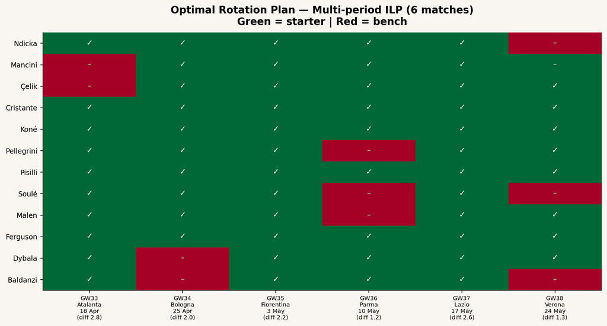

Multi-period ILP — Optimal rotation plan over 6 matches

[output not shown]

```python
# Schedule for the last 6 matches with estimated difficulty (1=easy, 3=hard)
# Updated to April 11, 2026 — GW32 already played (Roma-Pisa 3-0)
schedule = pd.DataFrame({
    "GW":         [33,          34,        35,             36,       37,       38],
    "Opponent":   ["Atalanta",  "Bologna", "Fiorentina",   "Parma",  "Lazio",  "Verona"],
    "Date":       ["18 Apr",    "25 Apr",  "3 May",        "10 May", "17 May", "24 May"],
    "Difficulty": [2.8,         2.0,       2.2,            1.2,      2.6,      1.3],
    "Home":       [True,        False,     True,           False,    True,     False],
})

players_rot = players[players["Role"] != "GK"].copy()
players_rot["MaxMatches"] = [5, 5, 5, 6, 6, 5, 6, 4, 5, 6, 5, 4, 6, 6, 5]

prob2 = pulp.LpProblem("Roma_Rotations", pulp.LpMaximize)

matchdays = list(range(len(schedule)))
names_r   = players_rot["Name"].tolist()
score_r   = dict(zip(players_rot["Name"], players_rot["G+A"]))
max_m     = dict(zip(players_rot["Name"], players_rot["MaxMatches"]))
role_r    = dict(zip(players_rot["Name"], players_rot["Role"]))

x2   = pulp.LpVariable.dicts("rot", [(n,t) for n in names_r for t in matchdays], cat="Binary")
diff = schedule["Difficulty"].tolist()

prob2 += pulp.lpSum(score_r[n] * diff[t] * x2[n,t]
                    for n in names_r for t in matchdays)

roles_req = {"DEF": 3, "MID": 4, "FWD": 3}
by_role_r = players_rot.groupby("Role")["Name"].apply(list).to_dict()

for t in matchdays:
    for role, req in roles_req.items():
        prob2 += pulp.lpSum(x2[n,t] for n in by_role_r[role]) == req

for n in names_r:
    prob2 += pulp.lpSum(x2[n,t] for t in matchdays) <= max_m[n]

prob2.solve(pulp.PULP_CBC_CMD(msg=0))

mat = np.zeros((len(names_r), len(matchdays)))
for i, n in enumerate(names_r):
    for t in matchdays:
        mat[i, t] = pulp.value(x2[n, t])

mask   = mat.sum(axis=1) > 0
mat_f  = mat[mask]
names_f = [names_r[i] for i in range(len(names_r)) if mask[i]]

fig, ax = plt.subplots(figsize=(11, 6))
im = ax.imshow(mat_f, aspect="auto", cmap="RdYlGn", vmin=0, vmax=1)

ax.set_xticks(range(len(schedule)))
ax.set_xticklabels([f"GW{c['GW']}\n{c['Opponent']}\n{c['Date']}\n(diff {c['Difficulty']})"
                    for _, c in schedule.iterrows()], fontsize=7.5)
ax.set_yticks(range(len(names_f)))
ax.set_yticklabels(names_f, fontsize=9)
ax.set_title("Optimal Rotation Plan — Multi-period ILP (6 matches)\n"
             "Green = starter | Red = bench", pad=10)

for i in range(len(names_f)):
    for j in range(len(matchdays)):
        txt = "✓" if mat_f[i,j] == 1 else "–"
        col = "white" if mat_f[i,j] == 1 else "#999"
        ax.text(j, i, txt, ha="center", va="center", fontsize=10,
                fontweight="bold", color=col)

plt.tight_layout()
plt.savefig("chart_rotations.png", dpi=150, bbox_inches="tight")
plt.show()

matches_tot = {n: int(mat[i].sum()) for i, n in enumerate(names_r) if mask[i]}
print("Starting appearances per player (optimal plan):")
for n, m in sorted(matches_tot.items(), key=lambda x: -x[1]):
    print(f"  {n:15s}: {m}/6 matches")
```

### 8.3 Stochastic Programming — Managing Result Uncertainty

#### 8.3.1 Why points are not certain

A deterministic model assumes every lineup produces a fixed result. In reality, points per match follow a **probability distribution**: Roma can win, draw or lose with different probabilities depending on the opponent and the chosen lineup.

**Stochastic Programming** incorporates this uncertainty by optimizing the **expected value** of points rather than a fixed value.

$$\max \mathbb{E}\left[\sum_{t=1}^{6} P_t(\text{lineup}_t)\right]
= \max \sum_{t=1}^{6} \left[ 3 \cdot p^W_t + 1 \cdot p^D_t \right]$$

[figure not shown]

Stochastic Programming — Expected points by lineup scenario

```python
np.random.seed(42)

def win_prob(form_score, difficulty, home):
    base = 0.45 if home else 0.30
    score_bonus = (form_score - 30) / 60
    diff_malus  = (difficulty - 1.5) / 3
    p = base + 0.25 * score_bonus - 0.15 * diff_malus
    return np.clip(p, 0.10, 0.75)

def draw_prob(p_win):
    return np.clip(0.25 - 0.1 * p_win, 0.10, 0.30)

score_optimal = 47
score_reduced = 35

N_sim = 10000
results = {}

for gw_idx, row in schedule.iterrows():
    for config, sc in [("Lineup A\n(starters)", score_optimal),
                       ("Lineup B\n(rotations)", score_reduced)]:
        pw  = win_prob(sc, row["Difficulty"], row["Home"])
        pd_ = draw_prob(pw)
        pl  = 1 - pw - pd_

        outcomes = np.random.choice([3, 1, 0], size=N_sim, p=[pw, pd_, pl])
        key = (row["Opponent"], config)
        results[key] = outcomes

pts_A = sum(results[(row["Opponent"], "Lineup A\n(starters)")]
            for _, row in schedule.iterrows())
pts_B = sum(results[(row["Opponent"], "Lineup B\n(rotations)")]
            for _, row in schedule.iterrows())

fig, axes = plt.subplots(1, 2, figsize=(12, 4.5))
fig.suptitle("Stochastic Programming — Points Distribution (10,000 simulations)",
             fontsize=13, fontweight="bold", color=GRAY)

for ax, pts, label, col in zip(
        axes,
        [pts_A, pts_B],
        ["Lineup A (starters)", "Lineup B (heavy rotations)"],
        [RED, GRAY]):
    ax.hist(pts, bins=30, color=col, alpha=0.80, edgecolor="white", linewidth=0.4)
    mu, sd = pts.mean(), pts.std()
    ax.axvline(mu,  color="black", linewidth=2,   label=f"Mean: {mu:.1f} pts")
    ax.axvline(68,  color=YELLOW,  linewidth=1.5, linestyle="--", label="CL top-5 threshold (68)")
    ax.axvline(72,  color=RED,     linewidth=1.5, linestyle=":",  label="CL top-4 threshold (72)")
    prob_cl5 = (pts >= 68).mean()
    prob_cl4 = (pts >= 72).mean()
    ax.set_title(f"{label}\nP(CL top-5) = {prob_cl5:.1%} | P(CL top-4) = {prob_cl4:.1%}")
    ax.set_xlabel("Final points (57 current + 6 matches)")
    ax.set_ylabel("Frequency")
    ax.legend(fontsize=7.5)

plt.tight_layout()
plt.savefig("chart_stochastic.png", dpi=150, bbox_inches="tight")
plt.show()
```

### 8.4 Opponent-Specific Assignment Model

#### 8.4.1 Model logic

Different opponents require different lineups. An **assignment model** maps each opponent type to the most suitable formation and players, based on:

- Opponent playing style (high press / low block / counter-attack)
- Historical head-to-head data
- Player characteristics in that specific context

[figure not shown]

Assignment model — Lineup score by opponent type

```python
opponent_profiles = {
    "High press\n(Atalanta, Lazio)":    {"pressing": 3, "high_line": 1, "counter": 1},
    "Low block\n(Parma, Verona)":       {"pressing": 1, "high_line": 0, "counter": 2},
    "Possession\n(Bologna, Fiorentina)":{"pressing": 2, "high_line": 1, "counter": 1},
    "Counter-attack\n(away variant)":   {"pressing": 1, "high_line": 0, "counter": 3},
}

player_context = pd.DataFrame({
    "Name":        ["Malen",   "Soulé",   "Ferguson","Dybala",  "Dovbyk",
                    "Pellegrini","Koné",  "Cristante","Pisilli", "El Shaarawy"],
    "Role":        ["FWD","FWD","FWD","FWD","FWD","MID","MID","MID","MID","FWD"],
    "vs_press":    [9,    8,    7,    6,    5,    8,    9,    7,    6,    5],
    "vs_low":      [7,    8,    8,    9,    9,    7,    6,    7,    7,    8],
    "vs_poss":     [8,    8,    7,    8,    6,    9,    8,    8,    7,    6],
    "vs_counter":  [7,    7,    6,    7,    8,    7,    8,    9,    8,    6],
})

context_cols   = ["vs_press", "vs_low", "vs_poss", "vs_counter"]
context_labels = list(opponent_profiles.keys())

fig, axes = plt.subplots(1, 4, figsize=(14, 5), sharey=True)
fig.suptitle("Player Assignment by Opponent Type\n(context score 1–10)",
             fontsize=12, fontweight="bold", color=GRAY)

for ax, (label, profile), col_key in zip(
        axes, opponent_profiles.items(), context_cols):

    df_c = player_context[["Name", col_key]].sort_values(col_key, ascending=True)
    bar_colors_c = [RED if v >= 8 else (YELLOW if v >= 7 else GRAY)
                    for v in df_c[col_key]]

    ax.barh(df_c["Name"], df_c[col_key], color=bar_colors_c, alpha=0.88,
            edgecolor="white", linewidth=0.4)
    ax.set_xlim(0, 11)
    ax.set_title(label, fontsize=8.5, pad=6)
    ax.axvline(x=8, color=RED, linestyle="--", linewidth=1, alpha=0.6)

    for i, (_, row) in enumerate(df_c.iterrows()):
        ax.text(row[col_key] + 0.1, i, str(row[col_key]),
                va="center", fontsize=7.5, color=GRAY)

axes[0].set_xlabel("Context rating")

p1 = mpatches.Patch(color=RED,    alpha=0.88, label="Ideal (≥8)")
p2 = mpatches.Patch(color=YELLOW, alpha=0.88, label="Good (7)")
p3 = mpatches.Patch(color=GRAY,   alpha=0.88, label="Alternative (<7)")
fig.legend(handles=[p1,p2,p3], loc="lower center", ncol=3, fontsize=8,
           bbox_to_anchor=(0.5, -0.02))

plt.tight_layout()
plt.savefig("chart_assignment.png", dpi=150, bbox_inches="tight")
plt.show()
```

**How it works in practice**: before each match, the opponent’s profile is identified, the corresponding column is read and players with score ≥ 8 are prioritized. Against a **low block** (Parma, Verona) Dovbyk and Dybala become more useful than Malen; against **high press** (Atalanta, Lazio) Malen and Koné are the optimal choice. The assignment model does not replace Gasperini’s 3-4-3: it *personalizes* it match by match.

## 9 Conclusion

The OR analysis confirms that Roma **does not need a revolution** for the Champions League: the quality is already in the squad. The levers are:

1. **Consistency** (especially away from home)
2. **Finishing efficiency** (closing the xG gap)
3. **Intelligent rotations** (preserving top players for decisive matches)

The ILP model is a tool, not an oracle: it must be integrated with the coach’s tactical judgment and qualitative information (injuries, form, dressing-room dynamics). But it makes explicit what the data say, reducing the risk of decisions driven only by intuition or emotion.